# House sales in King County USA

Daniela Quintero Narvaez Aleksander Karbowiak

2024-02-05

## House sales in King County USA - Regression problem

Real estate purchases have always been a burning topic. Should you invest your savings in a house or put it in a deposit? And if a buyer has already decided to buy a plot of land, the question arose as to which one to choose? And above all, is the property really worth the price?

In this project, we will try to research and predict U.S. home prices from King County of Washington State. The dataset comes from https://www.kaggle.com/datasets/shivachandel/kc-house-data and consists of historic data of houses sold between May 2014 to May 2015.

```r
house_data <- read.csv(file="r1.csv",header=TRUE,sep=",")
str(house_data)
```

```
## 'data.frame':    26795 obs. of  31 variables:
##  $ id           : int  1 2 3 4 5 6 7 8 9 10 ...
##  $ bathrooms    : num  3.25 1.75 2.25 3 2 2 1.75 1 2 3.5 ...
##  $ bedrooms     : int  4 3 4 2 4 3 4 2 3 6 ...
##  $ condition    : int  3 5 3 3 3 4 3 3 3 3 ...
##  $ date         : int  1401235207 1424736007 1402617607 1399248007 1427241607 1406678407 1406160007 1408320007 1408492807 1405814407 ...
##  $ feat01       : num  0.43 0.955 0.728 0.321 0.961 ...
##  $ feat02       : num  0.603 0.515 0.433 0.518 0.529 ...
##  $ feat03       : num  0.695 0.223 0.795 0.236 0.583 ...
##  $ feat04       : num  0.3106 0.806 0.306 0.0489 0.9978 ...
##  $ feat05       : num  0.506 0.374 0.43 0.39 0.5 ...
##  $ feat06       : num  0.4357 0.0234 0.7412 0.833 0.3574 ...
##  $ feat07       : num  0.394 0.556 0.124 0.495 0.519 ...
##  $ feat08       : num  0.68859 0.00761 0.17641 0.45371 0.55569 ...
##  $ feat09       : num  0.2762 0.8218 0.0896 0.4757 0.5348 ...
```

[output cut: 17 more lines]

Dataset has 31 variables and 26 795 observations.

Variables description:  
- id: A unique identification number for each transaction.  
- date: Date of house purchase.  
- price: Selling price of the house. It is our dependent variable.  
- bedrooms: Number of bedrooms in the house.  
- bathrooms: Number of bathrooms in the house.  
- sqft_living: Living area in square feet.  
- sqft_lot: Lot area in square feet.  
- floors: Number of floors of the house.  
- waterfront: Variable marking whether the house has a water (see, lake etc.) view (value 1 if yes, 0 otherwise).  
- view: Rate of view from the house (values from 0 to 4).  
- condition: Overall condition of the house (values from 1 to 5).  
- grade: Evaluates the quality of construction and design of the house (values from 1 to 13).  
- sqft_above: Living area of the top floor.  
- sqft_basement: Living area of the basement.  
- yr_built: Year the house was built.  
- yr_renovated: Year of most recent renovation (if any).  
- zipcode: Postal code of the area.  
- lat: Latitude.  
- long: Longitude.  
- sqft_living15: Average living area of the 15 nearest houses.  
- sqft_lot15: Average lot area of the 15 nearest houses.  
- feat01 <-> feat10: features without business meanings.

## Initial analysis

First of all we are going to check if our dataset has NA’s or duplicateted values.

```
##            id     bathrooms      bedrooms     condition          date
##             0             0             0             0             0
##        feat01        feat02        feat03        feat04        feat05
##             0             0             0             0             0
##        feat06        feat07        feat08        feat09        feat10
##             0             0             0             0             0
##        floors         grade           lat          long         price
##             0             0             0             0             0
##    sqft_above sqft_basement   sqft_living sqft_living15      sqft_lot
##             0             0             0             0             0
##    sqft_lot15          view    waterfront      yr_built  yr_renovated
##             0             0             0             0             0
##       zipcode
##             0
```

```
## [1] "Duplicates check"
```

```
## ramka danych z zerową liczbą kolumn oraz 26795 wierszami
```

As we can see there is no NA’s and no duplicates.

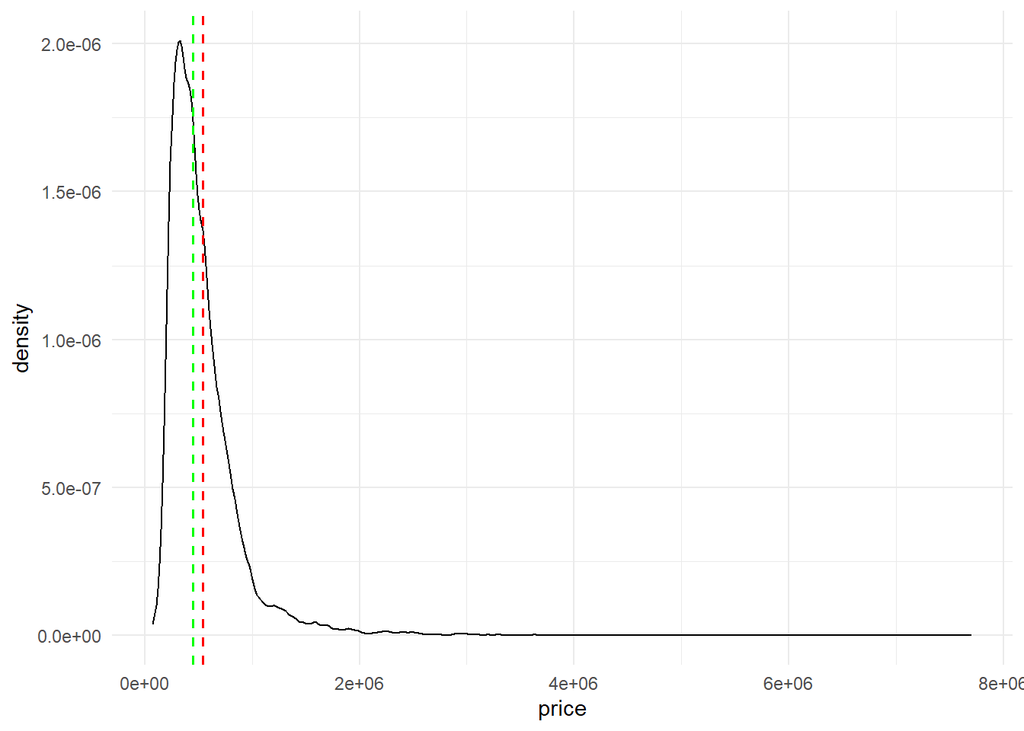

```r
#distribution of price var
a <- ggplot(house_data, aes(x = price))
a + geom_density() +
  geom_vline(aes(xintercept = mean(price)),
             linetype = "dashed", size = 0.6, colour="red") + geom_vline(aes(xintercept = median(price)),
                                                           linetype = "dashed", size = 0.6, colour="green") + scale_x_continuous() + theme_minimal()
```

```r
paste0("Mean price: ",mean(house_data$price))
```

```
## [1] "Mean price: 540920.034782609"
```

```r
paste0("Median price: ",median(house_data$price))
```

```
## [1] "Median price: 451246"
```

Above there is a distribution of our target variable - price. As we can see the distribution is right skewed. Mean is higher than median. There are outliers with huge values.

Another part of analysis is correlation check. We wanted to find varaibles that can be significant.

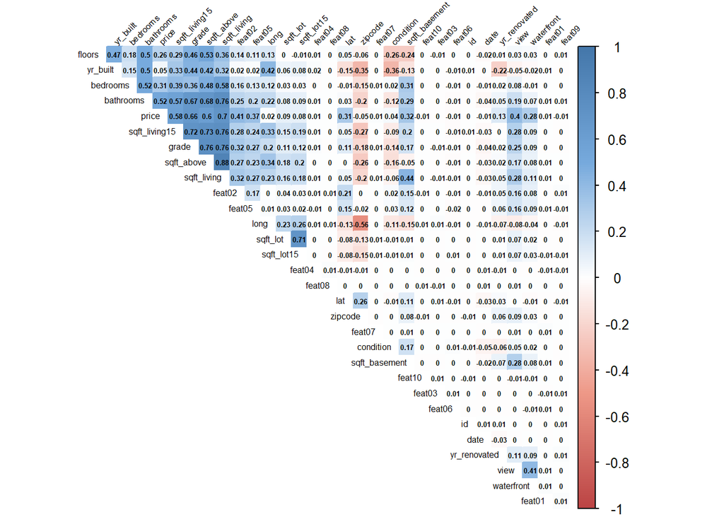

```r
#correlation
res <- cor(house_data)

col <- colorRampPalette(c("#BB4444", "#EE9988", "#FFFFFF", "#77AADD", "#4477AA"))
corrplot(res, method="color", col=col(200),
         type="upper", order="hclust",
         addCoef.col = "black", # Add coefficient of correlation
         tl.col="black", tl.srt=45, #Text label color and rotation
         # Combine with significance
        sig.level = 0.01, insig = "blank",
         # hide correlation coefficient on the principal diagonal
         diag=FALSE , number.cex = 0.4, tl.cex = 0.5
)
```

```r
library(leaflet)
quartiles <- quantile(house_data$price, probs=c(.25, .99), na.rm = FALSE)
IQR <- IQR(house_data$price)
Lower <- quartiles[1] - 1.5*IQR
Upper <- quartiles[2] + 1.5*IQR
# Sort the data by price in descending order
sorted_data <- house_data[order(-house_data$price), ]

# Select the top 30 houses with the highest prices
top_100_high_price <- head(sorted_data, 200)

# Select the top 30 houses with the lowest prices
top_100_low_price <- tail(sorted_data, 200)
top_99_quantile_high_price <- subset(sorted_data, price>=Upper)
# Combine the selected dataframes
selected_data <- rbind(top_100_high_price, top_100_low_price)

# Define colors for the map
selected_data$markerColor <- ifelse(selected_data$price %in% top_99_quantile_high_price$price, "gold", ifelse(selected_data$price %in% top_100_high_price$price,"blue","green"))

map <- leaflet(selected_data) %>%
  addTiles() %>%
  addCircleMarkers(
    lng = ~long,
    lat = ~lat,
    label = ~price,
    radius = 5,
    color = ~markerColor,
    fillOpacity = 0.8
  ) %>%
  addLegend("bottomright", colors = c("gold","blue" ,"green"), labels = c("TOP 99th quantile $$$","Top 200 $$$", "The Cheapest 200 $"), opacity = 1)

map
```

[interactive chart not shown]

Based on the map above we can see that localization matters. In the city center of Seattle there are the most expensive parcels. On the south of the city we can observe the cheapest homes.

To select key features for our final model we have also decided to examine variable importance based on default regression trees.

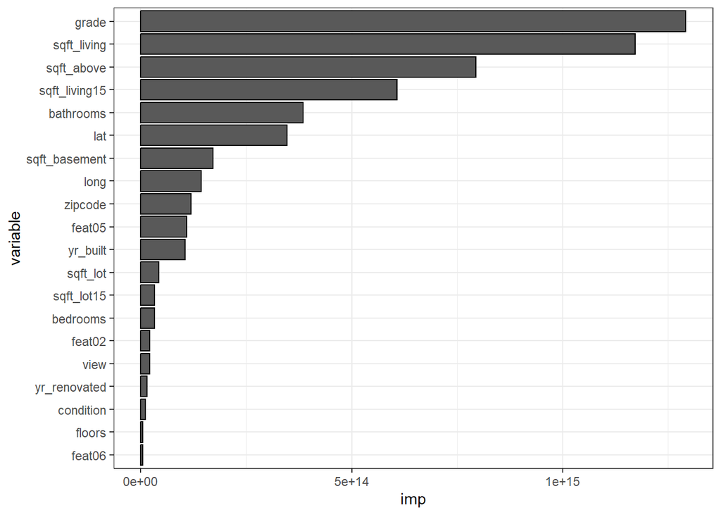

```r
House.treeRPARTReduced <- rpart(price~.,
                     data = house_data,
                     method = "anova")

#var importance
df <- data.frame(imp = House.treeRPARTReduced$variable.importance)
df2 <- df %>%
  tibble::rownames_to_column() %>%
  dplyr::rename("variable" = rowname) %>%
  dplyr::arrange(imp) %>%
  dplyr::mutate(variable = forcats::fct_inorder(variable))
ggplot2::ggplot(df2) +
  geom_col(aes(x = variable, y = imp),
           col = "black", show.legend = F) +
  coord_flip() +
  scale_fill_grey() +
  theme_bw()
```

Based on gathered information we have decided to built our final model.

```
## [1] "Final formula: price ~ feat02 + feat05 + view + grade + sqft_above + sqft_living + sqft_living15 + bathrooms + lat + long + yr_built + floors + condition + waterfront + bedrooms"
```

## Data preparation and split

```r
formula_based_on_rpart_importance = price ~ feat02 + feat05 + view + grade + sqft_above + sqft_living +sqft_living15 + bathrooms + lat + long + yr_built + floors + condition+waterfront+bedrooms;
#deal with outliers in key variables
important_features <- c("feat02","feat05","view","grade","sqft_above","sqft_living15","sqft_living","bathrooms","bedrooms","lat","long","yr_built","floors","condition")

for (i in important_features) {
  quantiles <- quantile(house_data[[i]], c(0.01, 0.99))
  house_data <- house_data %>%
    mutate({{i}} := ifelse(house_data[[i]] < quantiles[1], quantiles[1],
                           ifelse(house_data[[i]] > quantiles[2], quantiles[2], house_data[[i]])))
}

#delete outliers in Y var
quartiles <- quantile(house_data$price, probs=c(.25, .99), na.rm = FALSE)
IQR <- IQR(house_data$price)
Lower <- quartiles[1] - 1.5*IQR
Upper <- quartiles[2] + 1.5*IQR
data_no_outlier <- subset(house_data, house_data$price < Upper)


set.seed(123456789)
training_obs <- createDataPartition(house_data$price,
                                    p = 0.7,
                                    list = FALSE)
House.train <- house_data[training_obs,]
House.test  <- house_data[-training_obs,]

#Balanced data
House.train.balanced <- SmoteRegress(formula_based_on_rpart_importance, House.train,rel = "auto", thr.rel = 0.01, C.perc = "extreme",k = 5, repl = FALSE, dist = "Euclidean", p = 2)

training_obs2 <- createDataPartition(data_no_outlier$price,p = 0.7,list = FALSE)
House.train2 <- data_no_outlier[training_obs2,]
House.test2  <- data_no_outlier[-training_obs2,]
```

## General GLM model

```r
House.glmFull <- glm(formula_based_on_rpart_importance, data=House.train)
summary(House.glmFull)
```

```
##
## Call:
## glm(formula = formula_based_on_rpart_importance, data = House.train)
##
## Coefficients:
##                 Estimate Std. Error t value Pr(>|t|)
## (Intercept)   -3.549e+07  1.773e+06 -20.013   <2e-16 ***
## feat02         3.059e+05  1.465e+04  20.872   <2e-16 ***
## feat05         3.262e+05  1.416e+04  23.044   <2e-16 ***
## view           4.618e+04  2.393e+03  19.302   <2e-16 ***
## grade          9.471e+04  2.473e+03  38.301   <2e-16 ***
## sqft_above     5.014e+01  5.087e+00   9.856   <2e-16 ***
## sqft_living    9.715e+01  5.140e+00  18.901   <2e-16 ***
## sqft_living15  3.861e+01  4.034e+00   9.572   <2e-16 ***
## bathrooms      4.683e+04  3.746e+03  12.500   <2e-16 ***
## lat            4.937e+05  1.201e+04  41.090   <2e-16 ***
## long          -1.295e+05  1.340e+04  -9.664   <2e-16 ***
## yr_built      -2.414e+03  7.742e+01 -31.184   <2e-16 ***
## floors        -5.708e+03  4.085e+03  -1.397    0.162
## condition      2.393e+04  2.673e+03   8.954   <2e-16 ***
## waterfront     7.040e+05  1.986e+04  35.449   <2e-16 ***
## bedrooms      -2.567e+04  2.329e+03 -11.022   <2e-16 ***
## ---
## Signif. codes:  0 '***' 0.001 '**' 0.01 '*' 0.05 '.' 0.1 ' ' 1
##
## (Dispersion parameter for gaussian family taken to be 44114827507)
##
##     Null deviance: 2.5702e+15  on 18757  degrees of freedom
## Residual deviance: 8.2680e+14  on 18742  degrees of freedom
## AIC: 513011
##
## Number of Fisher Scoring iterations: 2
```

```r
House.glmFull.pred.train <- predict(House.glmFull, House.train)
print("MSE train")
```

```
## [1] "MSE train"
```

```r
(lm.MSE.train <- sum((House.glmFull.pred.train - House.train$price) ^ 2) / nrow(House.train))
```

```
## [1] 44077198909
```

```r
print("MAE train")
```

```
## [1] "MAE train"
```

```r
(lm.MAE.train <- sum(abs(House.glmFull.pred.train - House.train$price)) / nrow(House.train))
```

```
## [1] 125193.2
```

```r
House.glmFull.pred.test <- predict(House.glmFull, House.test)
print("MSE test")
```

```
## [1] "MSE test"
```

```r
(lm.MSE.test <- sum((House.glmFull.pred.test - House.test$price) ^ 2) / nrow(House.test))
```

```
## [1] 43951684560
```

```r
print("MAE test")
```

```
## [1] "MAE test"
```

```r
(lm.MAE.test <- sum(abs(House.glmFull.pred.test - House.test$price)) / nrow(House.test))
```

```
## [1] 126022.7
```

First of all we have checked how GLM model deals with our data. The outcome looks stable for train and test but are not satisfying.

## Decision Tree models

```r
House.treeFull <- tree(formula_based_on_rpart_importance, House.train)

#MSE for train
House.treeFull.TrainPred  <- predict(House.treeFull,  newdata = House.train)
paste("MSE for TRAIN = ",mean((House.treeFull.TrainPred- as.numeric(House.train$price)) ^ 2))
```

```
## [1] "MSE for TRAIN =  49220229442.8479"
```

```r
#MAE for train
paste("MAE for TRAIN =",mean(abs(House.treeFull.TrainPred- as.numeric(House.train$price))))
```

```
## [1] "MAE for TRAIN = 137586.843998676"
```

```r
#MSE for test
House.treeFull.TestPred  <- predict(House.treeFull,  newdata = House.test)
paste("MSE for TEST = ",mean((House.treeFull.TestPred- House.test$price) ^ 2))
```

```
## [1] "MSE for TEST =  51961748201.8317"
```

```r
#MAE for test
paste("MAE for TEST =",mean(abs(House.treeFull.TestPred- as.numeric(House.test$price))))
```

```
## [1] "MAE for TEST = 139309.453451428"
```

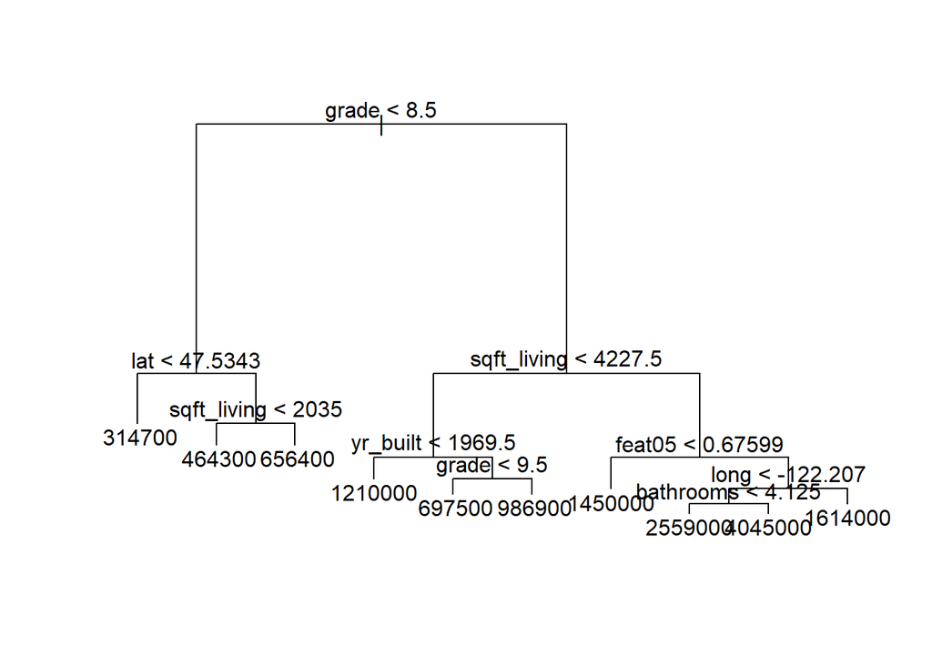

```r
plot(House.treeFull)
text(House.treeFull, pretty = 0)
```

Based on presented tree our model perform first split on grade variable. As we go deeper we can observe that our mysterious feat05 variable is taking part in the decisions process.

```r
House.treeReduced2 <- tree(formula_based_on_rpart_importance, data=House.train)
House.treeReduced2.TrainPred  <- predict(House.treeReduced2,  newdata = House.train)
paste("MSE for TRAIN = ",mean((House.treeReduced2.TrainPred- House.train$price) ^ 2))
```

```
## [1] "MSE for TRAIN =  49220229442.8479"
```

```r
paste("MAE for TRAIN = ",mean(abs(House.treeReduced2.TrainPred- House.train$price)))
```

```
## [1] "MAE for TRAIN =  137586.843998676"
```

```r
#on data without outliers
House.treeReducedWithoutOutliers2 <- tree(formula_based_on_rpart_importance, data=House.train2)
House.treeReducedWithoutOutliers2.TrainPred  <- predict(House.treeReducedWithoutOutliers2,  newdata = House.train2)
paste("MSE for Train Tree reduced = ",mean((House.treeReducedWithoutOutliers2.TrainPred- House.train2$price) ^ 2))
```

```
## [1] "MSE for Train Tree reduced =  32462325979.8992"
```

```r
paste("MAE for Train Tree reduced = ",mean(abs(House.treeReducedWithoutOutliers2.TrainPred- House.train2$price)))
```

```
## [1] "MAE for Train Tree reduced =  120421.880901238"
```

Then we decided to prune our trees.

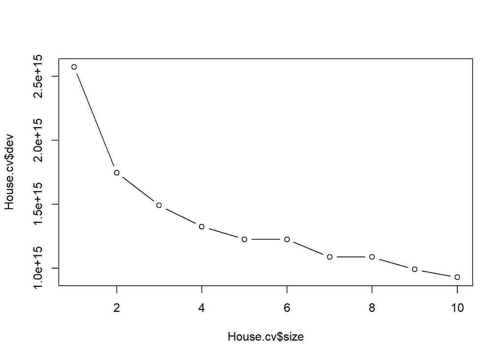

```r
House.cv <- cv.tree(House.treeReduced2, K = 15)
plot(House.cv$size, House.cv$dev, type = 'b')
```

```r
House.treeReduced2.pruned <- prune.tree(House.treeReduced2, best = 12)
House.treeReduced2.pruned.pred <- predict(House.treeReduced2.pruned,
                              newdata = House.test)
paste("MSE for TRAIN = ",mean((House.treeReduced2.pruned.pred   - House.test$price) ^ 2))
```

```
## [1] "MSE for TRAIN =  51961748201.8317"
```

```r
paste("MAE for TRAIN = ",mean(abs(House.treeReduced2.pruned.pred   - House.test$price)))
```

```
## [1] "MAE for TRAIN =  139309.453451428"
```

Pruning trees also also did not give us the expected better results.

For the best possible results we tried tuning hyperparameters.

```r
hyper_grid <- expand.grid(
  minsplit = seq(5, 20, 1),
  maxdepth = seq(8, 15, 1)
)
models <- list()
for (i in 1:nrow(hyper_grid)) {

  # setting the values
  minsplit <- hyper_grid$minsplit[i]
  maxdepth <- hyper_grid$maxdepth[i]

  # settin the seed
  set.seed(123123 + i)

  # training of the model and saving results to the list
  models[[i]] <- rpart(
    formula = formula_based_on_rpart_importance,
    data    = House.train.balanced,
    method  = "anova",
    control = list(minsplit = minsplit, maxdepth = maxdepth)
  )
}

get_cp <- function(x) {
  min <- which.min(x$cptable[, "xerror"])
  cp  <- x$cptable[min, "CP"]
  return(cp)
}

get_min_error <- function(x) {
  min    <- which.min(x$cptable[, "xerror"])
  xerror <- x$cptable[min, "xerror"]
  return(xerror)
}
hyper_grid %>%
  mutate(
    cp    = purrr::map_dbl(models, get_cp),
    error = purrr::map_dbl(models, get_min_error)
  ) %>%
  arrange(error) %>%
  top_n(-5, wt = error)
```

```
##   minsplit maxdepth   cp     error
## 1        5       15 0.01 0.3716834
## 2        8       14 0.01 0.3801100
## 3       18       13 0.01 0.3807421
## 4       10       10 0.01 0.3812367
## 5        6        9 0.01 0.3830743
```

```r
houses.tree.optimal <- rpart(
  formula = formula_based_on_rpart_importance,
  data    = House.train.balanced,
  method  = "anova",
  control = list(minsplit = 5, maxdepth = 15, cp = 0.01)
)

pred <- predict(houses.tree.optimal, newdata = House.train.balanced)

paste("MSE for TRAIN = ",mean((pred   - House.train.balanced$price) ^ 2))
```

```
## [1] "MSE for TRAIN =  52443712633.6099"
```

```r
paste("MAE for TRAIN = ",mean(abs(pred   - House.train.balanced$price)))
```

```
## [1] "MAE for TRAIN =  145711.284767056"
```

```r
pred_test <- predict(houses.tree.optimal, newdata = House.test)

paste("MSE for TEST = ",mean((pred_test   - House.test$price) ^ 2))
```

```
## [1] "MSE for TEST =  51172538725.3552"
```

```r
paste("MAE for TEST = ",mean(abs(pred_test   - House.test$price)))
```

```
## [1] "MAE for TEST =  139638.846701862"
```

As we can observe the results of different decisions trees are not better than GLM. We have to try different models.

## Random Forest models

The next model we have tried was Random Forest model.

```r
library(randomForest)

kingCounty.rf <- randomForest(formula_based_on_rpart_importance ,
                          data   = House.train.balanced,
                          mtry   = 5, ntree=300,nodesize=3,
                          importance = TRUE)

kingCounty.rf.pred <- predict(kingCounty.rf,
                          newdata = House.train.balanced)
paste("MSE for TRAIN = ",mean((kingCounty.rf.pred   - House.train.balanced$price) ^ 2))
```

```
## [1] "MSE for TRAIN =  3007618319.27593"
```

```r
paste("MAE for TRAIN = ",mean(abs(kingCounty.rf.pred   - House.train.balanced$price)))
```

```
## [1] "MAE for TRAIN =  29370.7388350477"
```

```r
kingCounty.rf.predt <- predict(kingCounty.rf,
                          newdata = House.test)
paste("MSE for TEST = ",mean((kingCounty.rf.predt   - House.test$price) ^ 2))
```

```
## [1] "MSE for TEST =  15815672013.3942"
```

```r
paste("MAE for TEST = ",mean(abs(kingCounty.rf.predt   - House.test$price)))
```

```
## [1] "MAE for TEST =  67773.5634169207"
```

## Gradient Boosting models

```r
House.gbm <- gbm(formula_based_on_rpart_importance,
                  data = House.train,
                  distribution = "gaussian",
                  n.trees = 600, #800
                  interaction.depth = 10, shrinkage=0.01)
House.gbm.pred <- predict(House.gbm,
                           newdata = House.train,
                           n.trees = 600,
                          interaction.depth = 10, shrinkage=0.01) #shrinkage is a key to disable overfitting
paste("MSE for TRAIN GBM = ",mean((House.gbm.pred - House.train$price) ^ 2))
```

```
## [1] "MSE for TRAIN GBM =  12883941235.5351"
```

```r
paste("MAE for TRAIN GBM = ",mean(abs(House.gbm.pred - House.train$price)))
```

```
## [1] "MAE for TRAIN GBM =  71891.2560508622"
```

```r
House.gbm.test_pred <- predict(House.gbm,
                                newdata = House.test,
                                n.trees = 600,
                               interaction.depth = 10, shrinkage=0.01)
paste("MSE for TEST GBM = ",mean((House.gbm.test_pred - House.test$price) ^ 2))
```

```
## [1] "MSE for TEST GBM =  17325817059.6651"
```

```r
paste("MAE for TEST GBM = ",mean(abs(House.gbm.test_pred - House.test$price)))
```

```
## [1] "MAE for TEST GBM =  76957.3263948813"
```

At first we have trained model on dataset with outliers done for independent variables. Outcomes looks good. MAE for TEST is on the level of 77k.

```r
#Balanced boosting
House_balanced.gbm <- gbm(formula_based_on_rpart_importance,
                 data = House.train.balanced,
                 distribution = "gaussian",
                 n.trees = 800,
                 interaction.depth = 10, shrinkage = 0.01)
House_balanced.gbm.pred <- predict(House_balanced.gbm,
                          newdata = House.train.balanced,
                          n.trees = 800,
                          interaction.depth = 10, shrinkage = 0.01)
paste("MSE for TRAIN GBM = ",mean((House_balanced.gbm.pred - House.train.balanced$price) ^ 2))
```

```
## [1] "MSE for TRAIN GBM =  15715294119.5367"
```

```r
paste("MAE for TRAIN GBM = ",mean(abs(House_balanced.gbm.pred - House.train.balanced$price)))
```

```
## [1] "MAE for TRAIN GBM =  79647.4272929099"
```

```r
House_balanced.gbm.test_pred <- predict(House_balanced.gbm,
                               newdata = House.test,
                               n.trees = 800,
                               interaction.depth = 10, shrinkage = 0.01)
paste("MSE for TEST GBM = ",mean((House_balanced.gbm.test_pred - House.test$price) ^ 2))
```

```
## [1] "MSE for TEST GBM =  17435791398.5842"
```

```r
paste("MAE for TEST GBM = ",mean(abs(House_balanced.gbm.test_pred - House.test$price)))
```

```
## [1] "MAE for TEST GBM =  77746.3719425425"
```

Then we have tried GBM on data balanced with SMOTE method. Results aren’t better than reulsts before. 77.7k for MAE TEST.

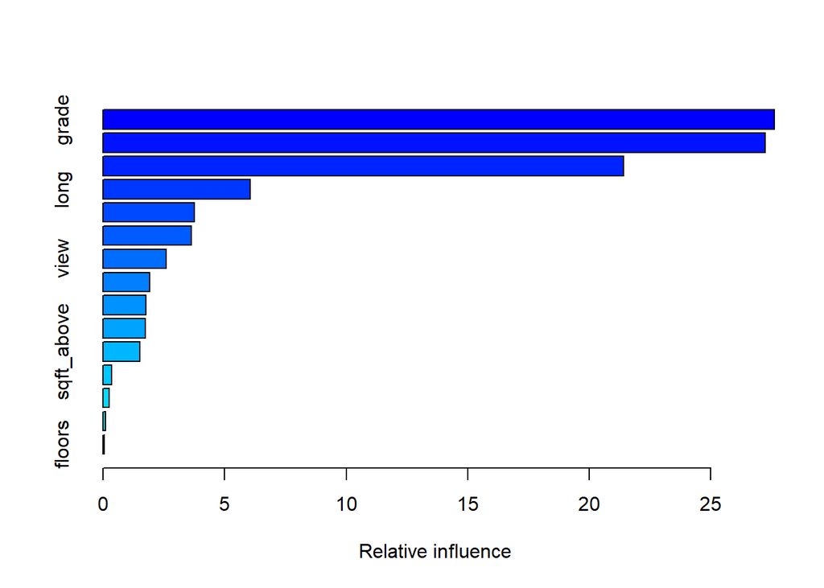

```
##                         var     rel.inf
## grade                 grade 27.60664882
## sqft_living     sqft_living 27.23733559
## lat                     lat 21.40028643
## long                   long  6.05081967
## yr_built           yr_built  3.76122246
## sqft_living15 sqft_living15  3.62178653
## view                   view  2.60481842
## waterfront       waterfront  1.93150619
## feat05               feat05  1.76259045
## feat02               feat02  1.75049385
## sqft_above       sqft_above  1.51220880
## bathrooms         bathrooms  0.35441572
## condition         condition  0.26174382
## bedrooms           bedrooms  0.10320579
## floors               floors  0.04091746
```

```r
House2.gbm <- gbm(formula_based_on_rpart_importance,
                  data = House.train2,
                  distribution = "gaussian",
                  n.trees = 800,
                  interaction.depth = 10, shrinkage = 0.01)
summary(House2.gbm)
```

```r
House2.gbm.pred <- predict(House2.gbm,
                           newdata = House.train2,
                           n.trees = 800,
                           interaction.depth = 10, shrinkage = 0.01)
paste("MSE for TRAIN GBM = ",mean((House2.gbm.pred - House.train2$price) ^ 2))
```

```
## [1] "MSE for TRAIN GBM =  9704935021.19292"
```

```r
paste("MAE for TRAIN GBM = ",mean(abs(House2.gbm.pred - House.train2$price)))
```

```
## [1] "MAE for TRAIN GBM =  66250.076459166"
```

```r
House2.gbm.test_pred <- predict(House2.gbm,
                           newdata = House.test2,
                           n.trees = 800,
                           interaction.depth = 10, shrinkage = 0.01)
paste("MSE for TEST GBM = ",mean((House2.gbm.test_pred - House.test2$price) ^ 2))
```

```
## [1] "MSE for TEST GBM =  11442644761.5984"
```

```r
paste("MAE for TEST GBM = ",mean(abs(House2.gbm.test_pred - House.test2$price)))
```

```
## [1] "MAE for TEST GBM =  69929.3325926873"
```

Results of GBM trained on data with all outliers reduced (Xs and Y) are also promising. MAE for TEST is on the level of 69k dollars.

```r
if (0) {
  grid <- expand.grid(interaction.depth = c(3, 7),
                      n.trees = c(100, 500, 1000),
                      shrinkage = c(0.01, 0.1),
                      n.minobsinnode = c(5, 7, 10, 15))

  House.gbm.tuned  <- train(formula_based_on_rpart_importance,
                             data = House.train,
                             distribution = "gaussian",
                             method = "gbm",
                             tuneGrid = grid,
                             verbose = FALSE)
  saveRDS(House.gbm.tuned, file= "House.gbm.tuned.rds")

}

House.gbm.tuned <- readRDS("House.gbm.tuned.rds")

# optimal parameters:
#House.gbm.tuned
# n.trees = 1000, interaction.depth = 7,
# shrinkage = 0.01 and n.minobsinnode = 10.

# retraining the model with optimal parameters
House.gbm3 <- gbm(formula_based_on_rpart_importance ,
                   data = House.train,
                   distribution = "gaussian",
                   n.trees = 1000,
                   interaction.depth = 7,
                   shrinkage = 0.01,
                   n.minobsinnode = 10,
                   verbose = F)
House.gbm3.train.pred <- predict(House.gbm3,
                           newdata = House.train,
                           n.trees = 1000)
paste("MSE for TRAIN GBM = ",mean((House.gbm3.train.pred - House.train$price) ^ 2))
```

```
## [1] "MSE for TRAIN GBM =  12233851764.36"
```

```r
paste("MAE for TRAIN GBM = ",mean(abs(House.gbm3.train.pred - House.train$price)))
```

```
## [1] "MAE for TRAIN GBM =  70896.0171943463"
```

```r
House.gbm3.pred <- predict(House.gbm3,
                            newdata = House.test,n.trees = 1000)
paste("MSE for TEST GBM = ",mean((House.gbm3.pred - House.test$price) ^ 2))
```

```
## [1] "MSE for TEST GBM =  16939712590.1686"
```

```r
paste("MAE for TEST GBM = ",mean(abs(House.gbm3.pred - House.test$price)))
```

```
## [1] "MAE for TEST GBM =  76291.5031917869"
```

## Neural Network models

For Neural Network analysis and training we have prepared standardized dataset and linear model as a benchmark.

```r
#Benchmark LM
lm.fit <- lm(formula_based_on_rpart_importance , data = House.train)
#summary(lm.fit)

lm.pred.train <- predict(lm.fit, House.train)
lm.MSE.train <- sum((lm.pred.train - House.train$price) ^ 2) / nrow(House.train)
lm.MAE.train <- sum(abs(lm.pred.train - House.train$price)) / nrow(House.train)

lm.pred <- predict(lm.fit, House.test)
lm.MSE <- sum((lm.pred - House.test$price) ^ 2) / nrow(House.test)
lm.MAE <- sum(abs(lm.pred - House.test$price)) / nrow(House.test)
train.maxs <- apply(House.train, 2, max)
train.mins <- apply(House.train, 2, min)


train.maxs2 <- apply(House.train2, 2, max)
train.mins2 <- apply(House.train2, 2, min)

train.maxs3 <- apply(House.train.balanced, 2, max)
train.mins3 <- apply(House.train.balanced, 2, min)

#Standarization
House.train %>% glimpse()
```

```
## Rows: 18,758
## Columns: 31
## $ id            <int> 1, 2, 3, 4, 5, 6, 8, 10, 11, 14, 15, 16, 17, 18, 19, 22,…
## $ bathrooms     <dbl> 3.25, 1.75, 2.25, 3.00, 2.00, 2.00, 1.00, 3.50, 2.50, 1.…
## $ bedrooms      <dbl> 4, 3, 4, 2, 4, 3, 2, 6, 3, 2, 5, 2, 5, 3, 4, 4, 4, 3, 2,…
## $ condition     <dbl> 3, 5, 3, 3, 3, 4, 3, 3, 3, 3, 4, 3, 5, 4, 3, 3, 3, 3, 3,…
## $ date          <int> 1401235207, 1424736007, 1402617607, 1399248007, 14272416…
## $ feat01        <dbl> 0.43029853, 0.95546494, 0.72826656, 0.32075230, 0.961231…
## $ feat02        <dbl> 0.6027601, 0.5148432, 0.4326415, 0.5176993, 0.5291457, 0…
## $ feat03        <dbl> 0.69465011, 0.22283881, 0.79542513, 0.23608109, 0.583253…
## $ feat04        <dbl> 0.310587907, 0.806001063, 0.305965286, 0.048934108, 0.99…
## $ feat05        <dbl> 0.5064748, 0.3740847, 0.4299024, 0.3896580, 0.5000309, 0…
## $ feat06        <dbl> 0.435688643, 0.023381619, 0.741205551, 0.832970180, 0.35…
## $ feat07        <dbl> 0.39406017, 0.55576829, 0.12409667, 0.49496895, 0.518812…
## $ feat08        <dbl> 0.688590810, 0.007612249, 0.176411242, 0.453705660, 0.55…
```

[output cut: 18 more lines]

```r
House.train.scaled <-
  as.data.frame(scale(House.train,
                      center = train.mins,
                      scale  = train.maxs - train.mins))
House.test.scaled <-
  as.data.frame(scale(House.test,
                      center = train.mins,
                      scale  = train.maxs - train.mins))



House.train2.scaled <-
  as.data.frame(scale(House.train2,
                      center = train.mins2,
                      scale  = train.maxs2 - train.mins2))
House.test2.scaled <-
  as.data.frame(scale(House.test2,
                      center = train.mins2,
                      scale  = train.maxs2 - train.mins2))


House.train3.scaled <-
  as.data.frame(scale(House.train.balanced,
                      center = train.mins3,
                      scale  = train.maxs3 - train.mins3))
```

Below we can observe results of our first trained neural network.

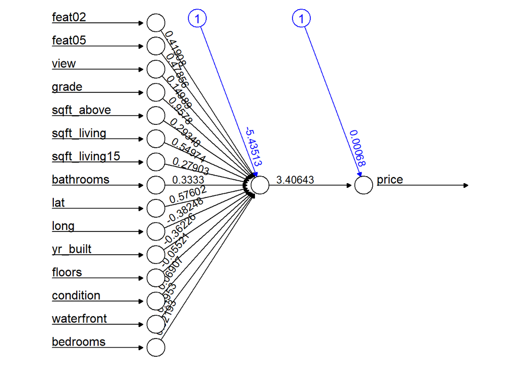

```r
nn1_2 <- neuralnet(formula_based_on_rpart_importance,
                data   = House.train.scaled,
                hidden = c(1),
                linear.output = T)
#Plot of neural network
plot(nn1_2, rep = "best")
```

```r
nn1_2.train.pred <- compute(nn1_2,subset(House.train.scaled, select=-price))
#scalling back
nn1_2.train.pred.unscaled <-
  nn1_2.train.pred$net.result *
  (train.maxs["price"] - train.mins["price"]) + train.mins["price"]
nn1_2.train.MSE <- sum((House.train$price - nn1_2.train.pred.unscaled)^2)/nrow(House.train)
nn1_2.train.MAE <- sum(abs(House.train$price - nn1_2.train.pred.unscaled))/nrow(House.train)
cat(paste0("Train MSE.lm = ", round(lm.MSE.train, 2), ", " ,
           "Train MSE.nn = ", round(nn1_2.train.MSE, 2)))
```

```
## Train MSE.lm = 44077198909.3, Train MSE.nn = 31466150567.45
```

```r
cat(paste0("Train MAE.lm = ", round(lm.MAE.train, 2), ", " ,
           "Train MAE.nn = ", round(nn1_2.train.MAE, 2)))
```

```
## Train MAE.lm = 125193.2, Train MAE.nn = 111104.12
```

```r
nn1_2.test.pred <- compute(nn1_2, subset(House.test.scaled, select=-price))
nn1_2.test.pred.unscaled <-
  nn1_2.test.pred$net.result *
  (train.maxs["price"] - train.mins["price"]) + train.mins["price"]
nn1_2.test.MSE <- sum((House.test$price - nn1_2.test.pred.unscaled)^2)/nrow(House.test)
nn1_2.test.MAE <- sum(abs(House.test$price - nn1_2.test.pred.unscaled))/nrow(House.test)
cat(paste0("Test MSE.lm = ", round(lm.MSE, 2), ", " ,
           "Test MSE.nn = ", round(nn1_2.test.MSE, 2)))
```

```
## Test MSE.lm = 43951684559.83, Test MSE.nn = 30454158607.62
```

```r
cat(paste0("Test MAE.lm = ", round(lm.MAE, 2), ", " ,
           "Test MAE.nn = ", round(nn1_2.test.MAE, 2)))
```

```
## Test MAE.lm = 126022.66, Test MAE.nn = 111316.6
```

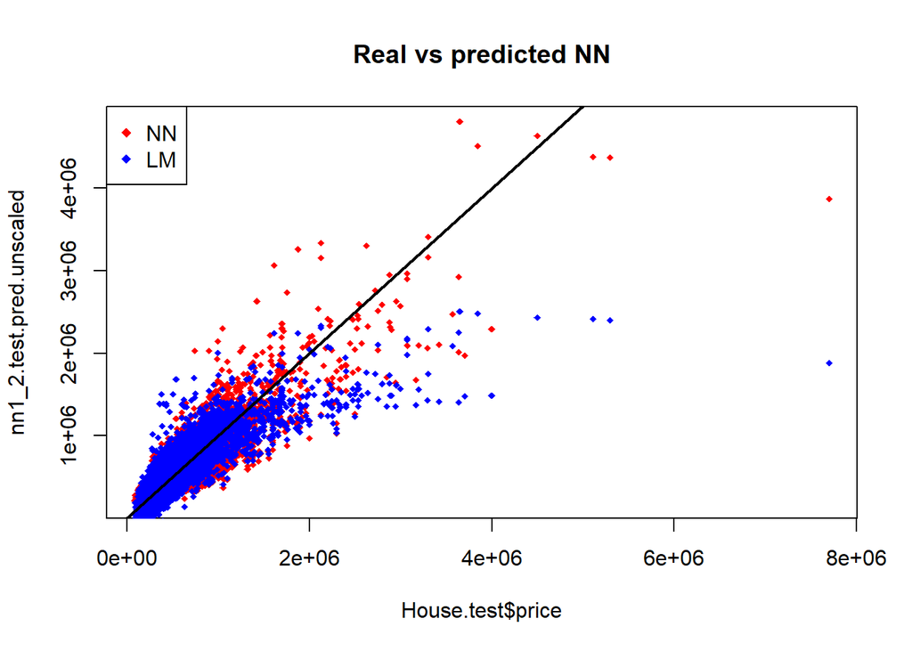

```r
#plot
plot(House.test$price,
     nn1_2.test.pred.unscaled,
     col = 'red', main = 'Real vs predicted NN', pch = 18, cex = 0.7)
points(House.test$price,
       lm.pred,
       col = 'blue', pch = 18, cex = 0.7)
abline(0, 1, lwd = 2)
legend('topleft', legend = c('NN', 'LM'),
       pch = 18, col = c('red', 'blue'))
```

As we can see basic NN (1 hidden layer) results are slightly better in comparison to linear model but still are not satysfing. For example gradient boosting models did much better.We can compare results of both models on scatter plot.

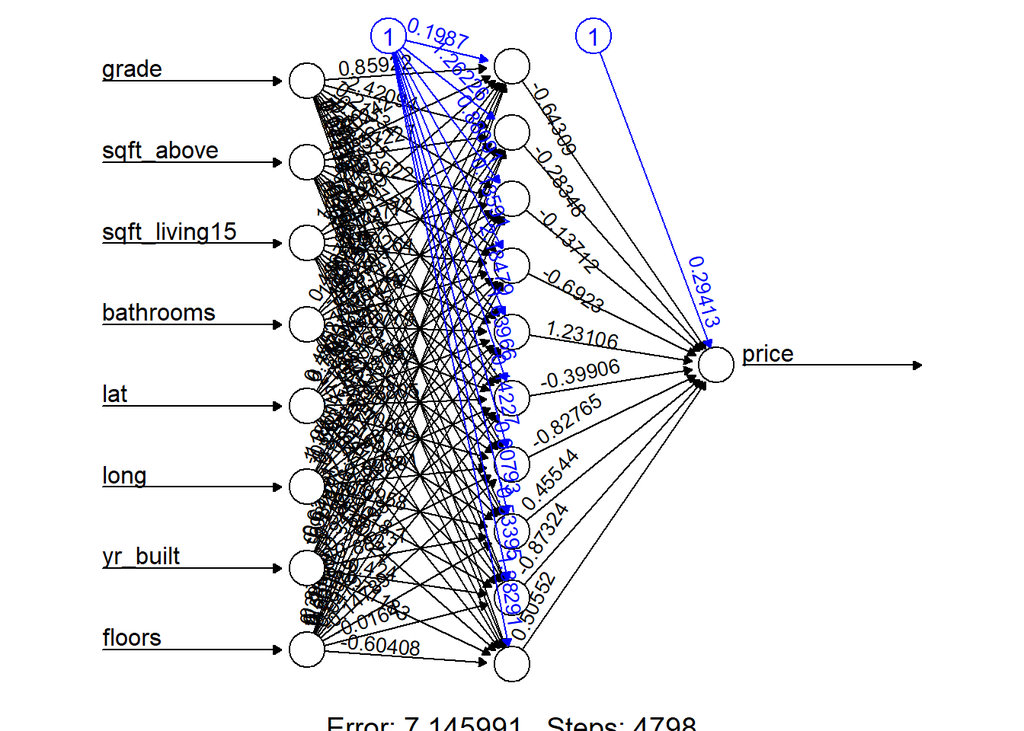

```r
if(0) {nn2 <- neuralnet(formula_based_on_rpart_importance,
                 data   = House.train.scaled,
                 hidden = c(10),
                 linear.output = T, threshold=0.2,stepmax=1e4)

saveRDS(nn2, file= "nn2.rds")
}


nn2 <- readRDS("nn2.rds")

plot(nn2, rep = "best")
```

```r
nn2.train.pred <- compute(nn2,subset(House.train.scaled, select=-price))
#scalling back
nn2.train.pred.unscaled <-
  nn2.train.pred$net.result *
  (train.maxs["price"] - train.mins["price"]) + train.mins["price"]
nn2.train.MSE <- sum((House.train$price - nn2.train.pred.unscaled)^2)/nrow(House.train)
nn2.train.MAE <- sum(abs(House.train$price - nn2.train.pred.unscaled))/nrow(House.train)
cat(paste0("Train MSE.lm = ", round(lm.MSE.train, 2), ", " ,
           "Train MSE.nn = ", round(nn2.train.MSE, 2)))
```

```
## Train MSE.lm = 44077198909.3, Train MSE.nn = 37186728875.97
```

```r
cat(paste0("Train MAE.lm = ", round(lm.MAE.train, 2), ", " ,
           "Train MAE.nn = ", round(nn2.train.MAE, 2)))
```

```
## Train MAE.lm = 125193.2, Train MAE.nn = 110112.46
```

```r
nn2.test.pred <- compute(nn2, subset(House.test.scaled, select=-price))
nn2.test.pred.unscaled <-
  nn2.test.pred$net.result *
  (train.maxs["price"] - train.mins["price"]) + train.mins["price"]
nn2.test.MSE <- sum((House.test$price - nn2.test.pred.unscaled)^2)/nrow(House.test)
nn2.test.MAE <- sum(abs(House.test$price - nn2.test.pred.unscaled))/nrow(House.test)
cat(paste0("Test MSE.lm = ", round(lm.MSE, 2), ", " ,
           "Test MSE.nn = ", round(nn2.test.MSE, 2)))
```

```
## Test MSE.lm = 43951684559.83, Test MSE.nn = 37708717049.12
```

```r
cat(paste0("Test MAE.lm = ", round(lm.MAE, 2), ", " ,
           "Test MAE.nn = ", round(nn2.test.MAE, 2)))
```

```
## Test MAE.lm = 126022.66, Test MAE.nn = 110576.31
```

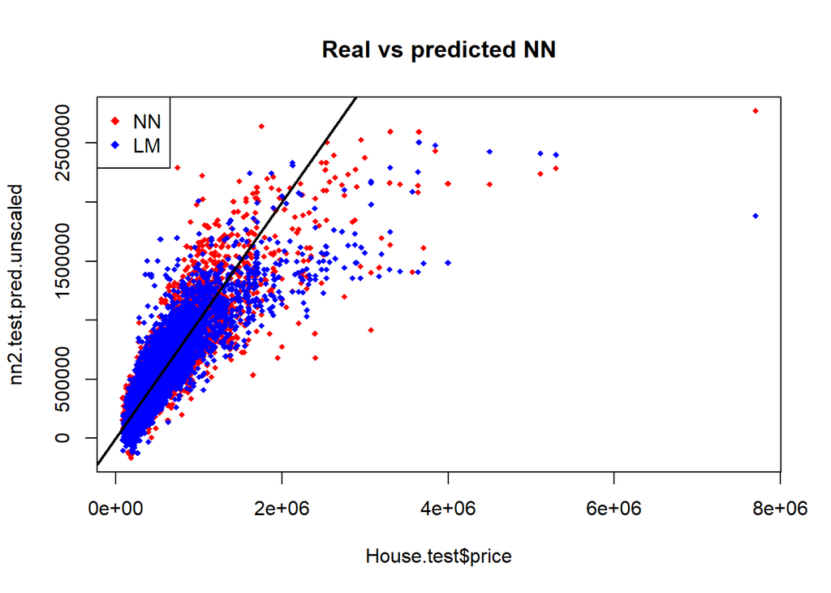

```r
#plot
plot(House.test$price,
     nn2.test.pred.unscaled,
     col = 'red', main = 'Real vs predicted NN', pch = 18, cex = 0.7)
points(House.test$price,
       lm.pred,
       col = 'blue', pch = 18, cex = 0.7)
abline(0, 1, lwd = 2)
legend('topleft', legend = c('NN', 'LM'),
       pch = 18, col = c('red', 'blue'))
```

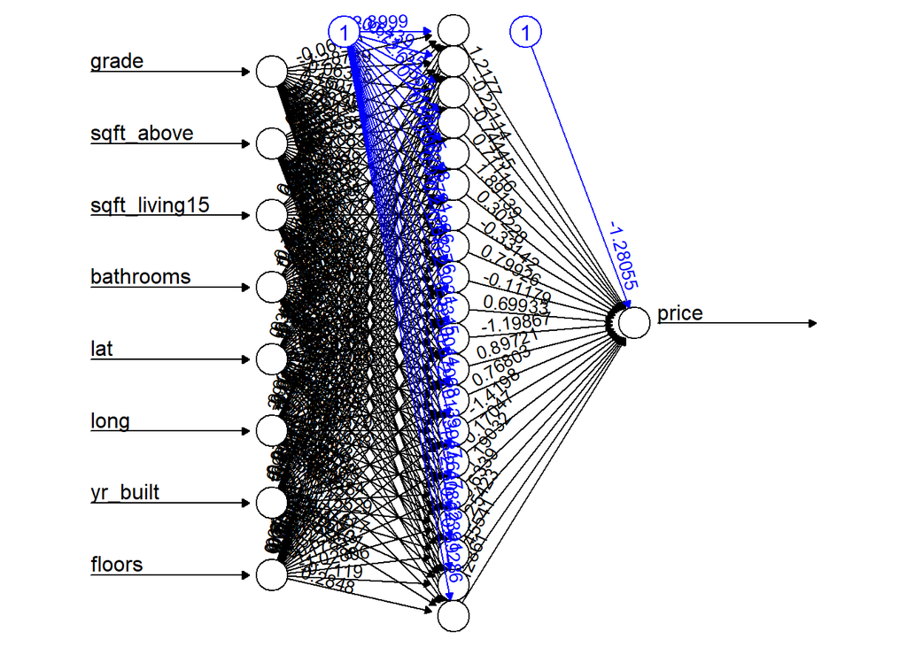

```r
if(0){
nn3 <- neuralnet(formula_based_on_rpart_importance,
                 data   = House.train.scaled,
                 hidden = c(20),
                 linear.output = T, threshold=0.2)

saveRDS(nn3, file= "nn3.rds")
}
nn3 <- readRDS("nn3.rds")

plot(nn3, rep = "best")
```

```r
nn3.train.pred <- compute(nn3,subset(House.train.scaled, select=-price))
#scalling back
nn3.train.pred.unscaled <-
  nn3.train.pred$net.result *
  (train.maxs["price"] - train.mins["price"]) + train.mins["price"]
nn3.train.MSE <- sum((House.train$price - nn3.train.pred.unscaled)^2)/nrow(House.train)
nn3.train.MAE <- sum(abs(House.train$price - nn3.train.pred.unscaled))/nrow(House.train)
cat(paste0("Train MSE.lm = ", round(lm.MSE.train, 2), ", " ,
           "Train MSE.nn = ", round(nn3.train.MSE, 2)))
```

```
## Train MSE.lm = 44077198909.3, Train MSE.nn = 31196504812.11
```

```r
cat(paste0("Train MAE.lm = ", round(lm.MAE.train, 2), ", " ,
           "Train MAE.nn = ", round(nn3.train.MAE, 2)))
```

```
## Train MAE.lm = 125193.2, Train MAE.nn = 99313.23
```

```r
nn3.test.pred <- compute(nn3, subset(House.test.scaled, select=-price))
nn3.test.pred.unscaled <-
  nn3.test.pred$net.result *
  (train.maxs["price"] - train.mins["price"]) + train.mins["price"]
nn3.test.MSE <- sum((House.test$price - nn3.test.pred.unscaled)^2)/nrow(House.test)
nn3.test.MAE <- sum(abs(House.test$price - nn3.test.pred.unscaled))/nrow(House.test)
cat(paste0("Test MSE.lm = ", round(lm.MSE, 2), ", " ,
           "Test MSE.nn = ", round(nn3.test.MSE, 2)))
```

```
## Test MSE.lm = 43951684559.83, Test MSE.nn = 32881256363.67
```

```r
cat(paste0("Test MAE.lm = ", round(lm.MAE, 2), ", " ,
           "Test MAE.nn = ", round(nn3.test.MAE, 2)))
```

```
## Test MAE.lm = 126022.66, Test MAE.nn = 100704.95
```

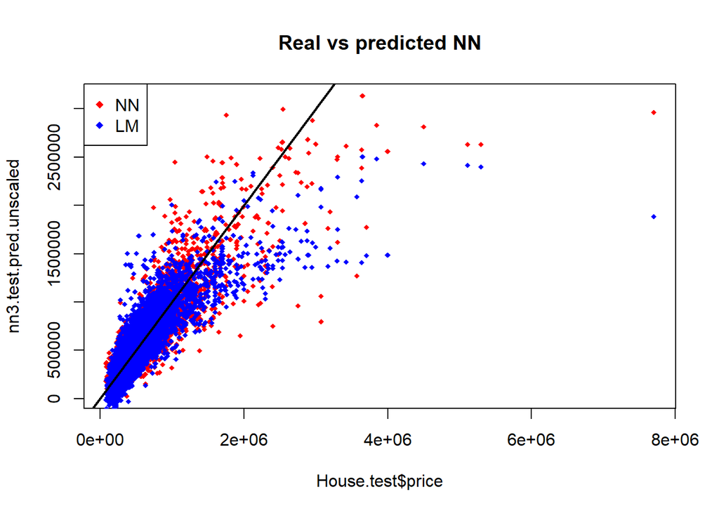

```r
#plot
plot(House.test$price,
     nn3.test.pred.unscaled,
     col = 'red', main = 'Real vs predicted NN', pch = 18, cex = 0.7)
points(House.test$price,
       lm.pred,
       col = 'blue', pch = 18, cex = 0.7)
abline(0, 1, lwd = 2)
legend('topleft', legend = c('NN', 'LM'),
       pch = 18, col = c('red', 'blue'))
```

```r
if(0){
nn3_2 <- neuralnet(formula_based_on_rpart_importance,
                 data   = House.train2.scaled,
                 hidden = c(20),
                 linear.output = T, threshold=0.2)

saveRDS(nn3_2, file= "nn3_2.rds")
}
nn3_2 <- readRDS("nn3_2.rds")




nn3_2.train.pred <- compute(nn3_2,subset(House.train2.scaled, select=-price))
#scalling back
nn3_2.train.pred.unscaled <-
  nn3_2.train.pred$net.result *
  (train.maxs2["price"] - train.mins2["price"]) + train.mins2["price"]
nn3_2.train.MSE <- sum((House.train2$price - nn3_2.train.pred.unscaled)^2)/nrow(House.train2)
nn3_2.train.MAE <- sum(abs(House.train2$price - nn3_2.train.pred.unscaled))/nrow(House.train2)
cat(paste0("Train MSE.lm = ", round(lm.MSE.train, 2), ", " ,
           "Train MSE.nn = ", round(nn3_2.train.MSE, 2)))
```

```
## Train MSE.lm = 44077198909.3, Train MSE.nn = 44153079842.54
```

```r
cat(paste0("Train MAE.lm = ", round(lm.MAE.train, 2), ", " ,
           "Train MAE.nn = ", round(nn3_2.train.MAE, 2)))
```

```
## Train MAE.lm = 125193.2, Train MAE.nn = 136865.34
```

```r
nn3_2.test.pred <- compute(nn3_2, subset(House.test, select=-price))
nn3_2.test.pred.unscaled <-
  nn3_2.test.pred$net.result *
  (train.maxs2["price"] - train.mins2["price"]) + train.mins2["price"]
nn3_2.test.MSE <- sum((House.test$price - nn3_2.test.pred.unscaled)^2)/nrow(House.test)
nn3_2.test.MAE <- sum(abs(House.test$price - nn3_2.test.pred.unscaled))/nrow(House.test)
cat(paste0("Test MSE.lm = ", round(lm.MSE, 2), ", " ,
           "Test MSE.nn = ", round(nn3_2.test.MSE, 2)))
```

```
## Test MSE.lm = 43951684559.83, Test MSE.nn = 27698075522599
```

```r
cat(paste0("Test MAE.lm = ", round(lm.MAE, 2), ", " ,
           "Test MAE.nn = ", round(nn3_2.test.MAE, 2)))
```

```
## Test MAE.lm = 126022.66, Test MAE.nn = 5005358.05
```

The outcomes of NN on TEST dataset without outliers in Y variable are the worst.

```r
if(0){
nn3_3 <- neuralnet(formula_based_on_rpart_importance,
                   data   = House.train3.scaled,
                   hidden = c(20),
                   linear.output = T, threshold=0.2)

saveRDS(nn3_3, file= "nn3_3.rds")
}
nn3_3 <- readRDS("nn3_3.rds")




nn3_3.train.pred <- compute(nn3_3,subset(House.train3.scaled, select=-price))
#scalling back
nn3_3.train.pred.unscaled <-
  nn3_3.train.pred$net.result *
  (train.maxs3["price"] - train.mins3["price"]) + train.mins3["price"]
nn3_3.train.MSE <- sum((House.train.balanced$price - nn3_3.train.pred.unscaled)^2)/nrow(House.train.balanced)
nn3_3.train.MAE <- sum(abs(House.train.balanced$price - nn3_3.train.pred.unscaled))/nrow(House.train.balanced)
cat(paste0("Train MSE.lm = ", round(lm.MSE.train, 2), ", " ,
           "Train MSE.nn = ", round(nn3_3.train.MSE, 2)))
```

```
## Train MSE.lm = 44077198909.3, Train MSE.nn = 30815885009.35
```

```r
cat(paste0("Train MAE.lm = ", round(lm.MAE.train, 2), ", " ,
           "Train MAE.nn = ", round(nn3_3.train.MAE, 2)))
```

```
## Train MAE.lm = 125193.2, Train MAE.nn = 113087.87
```

```r
nn3_3.test.pred <- compute(nn3_3, subset(House.test, select=-price))
nn3_3.test.pred.unscaled <-
  nn3_3.test.pred$net.result *
  (train.maxs2["price"] - train.mins2["price"]) + train.mins2["price"]
nn3_3.test.MSE <- sum((House.test$price - nn3_3.test.pred.unscaled)^2)/nrow(House.test)
nn3_3.test.MAE <- sum(abs(House.test$price - nn3_3.test.pred.unscaled))/nrow(House.test)
cat(paste0("Test MSE.lm = ", round(lm.MSE, 2), ", " ,
           "Test MSE.nn = ", round(nn3_3.test.MSE, 2)))
```

```
## Test MSE.lm = 43951684559.83, Test MSE.nn = 6663188919869.33
```

```r
cat(paste0("Test MAE.lm = ", round(lm.MAE, 2), ", " ,
           "Test MAE.nn = ", round(nn3_3.test.MAE, 2)))
```

```
## Test MAE.lm = 126022.66, Test MAE.nn = 2038180.74
```

Set balanced with SMOTE method also did not give us the expected better results.

## Summary and conclusions

The table below represents the results of our best tuned models. As we can see the values of MSE metric are huge in every case and it’s hard to interpret it in a business way. It’s likely that our models did not do the best job of predicting prices for the most expensive properties because they were represented by a small sample of data, which could powerfully increase the MSE. We can surmise that this is the reason for the high MSE. Thankfully MAE measure can tell us more. MAE for TEST sub sample was the smallest in case of Random Forest model. This value indicated that, on average, we made an error of $68,000 when predicting housing prices. This seems like a pretty good result, considering that we had cases of properties worth more than 1.5 million in our collection. Unfortunately, in the case of the random forest, things are no longer so colorful if we compare our results from the test set with those from the training set. On the training set, the MAE was 29K. Such a large discrepancy between the result of the learning sample and the test sample indicates that the model was overfitted. We cannot consider the random forest as our top model. The issue is different for the gradient boosting model. There, the MAE per TEST was 70k, which is marginally worse than the random forest. On TRAIN for the GBM, the MAE was 66K. Such a discrepancy between the TRAIN and TEST results may indicate a correct fit of the model to the US house price data. Therefore, our best model was the Gradient Boosting model.

| Model | Train_MSE | Train_MAE | Test_MSE | Test_MAE |
| --- | --- | --- | --- | --- |
| GLM | 44077 M | 125 K | 43952 M | 126 K |
| TREE | 52444 M | 146 K | 51173 M | 140 K |
| RF | 3008 M | 29 K | 15816 M | 68 K |
| GBM | 9705 M | 66 K | 11443 M | 70 K |
| NN | 31197 M | 99 K | 32881 M | 101 K |